# 🤖 BTC Wheel Bot — Complete Strategy Explainer

## 8 · Parameter sweep — sensitivity curves

The optimiser tested each parameter individually, sweeping it across a range while holding everything else fixed. The curves show you **how sensitive the bot's performance is to each parameter** — steep curves mean a parameter matters a lot; flat curves mean it's less important.

**Fitness score** is a composite metric: higher = better. It blends return, Sharpe ratio, win rate, and drawdown.

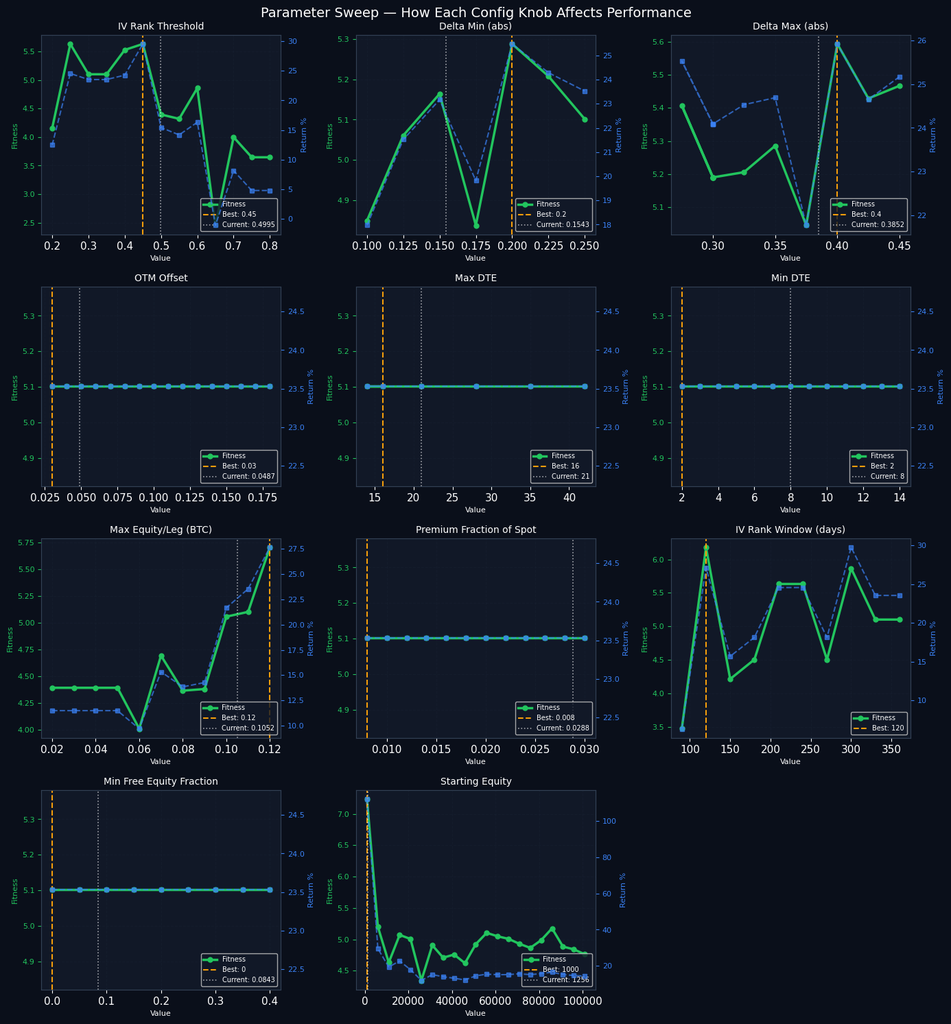

```
=== BEST VALUE PER PARAMETER ===
  ❓ IV Rank Threshold                  : best=    0.45  current=  0.4995  fitness=5.633
  ❓ Delta Min (abs)                    : best=     0.2  current=  0.1543  fitness=5.288
  ✅ Delta Max (abs)                    : best=     0.4  current=  0.3852  fitness=5.593
  ❓ OTM Offset                         : best=    0.03  current=  0.0487  fitness=5.102
  ❓ Max DTE                            : best=      16  current=      21  fitness=5.102
  ❓ Min DTE                            : best=       2  current=       8  fitness=5.102
  ❓ Max Equity/Leg (BTC)               : best=    0.12  current=  0.1052  fitness=5.705
  ❓ Premium Fraction of Spot           : best=   0.008  current=  0.0288  fitness=5.102
  ⚠️ IV Rank Window (days)              : best=     120  current=     N/A  fitness=6.178
  ❓ Min Free Equity Fraction           : best=       0  current=  0.0843  fitness=5.102
  ❓ Starting Equity                    : best=    1000  current=    1256  fitness=7.236
```

```python
sweep = sweep_raw   # top-level keys ARE the param names

param_labels = {
    'iv_rank_threshold':        'IV Rank Threshold',
    'target_delta_min':         'Delta Min (abs)',
    'target_delta_max':         'Delta Max (abs)',
    'approx_otm_offset':        'OTM Offset',
    'max_dte':                  'Max DTE',
    'min_dte':                  'Min DTE',
    'max_equity_per_leg':       'Max Equity/Leg (BTC)',
    'premium_fraction_of_spot': 'Premium Fraction of Spot',
    'iv_rank_window_days':      'IV Rank Window (days)',
    'min_free_equity_fraction': 'Min Free Equity Fraction',
    'starting_equity':          'Starting Equity',
}

params_found = [p for p in param_labels if p in sweep]
n    = len(params_found)
cols = 3
rows = max(1, math.ceil(n / cols))

fig, axes = plt.subplots(rows, cols, figsize=(14, rows * 3.8))
fig.suptitle('Parameter Sweep — How Each Config Knob Affects Performance', fontsize=14, color='white')
axes_flat = axes.flatten() if hasattr(axes, 'flatten') else [axes]

for i, param in enumerate(params_found):
    ax = axes_flat[i]
    entries = sweep[param]
    # x = the value of this parameter in each sweep entry
    xs      = [e['params'][param]       for e in entries]
    fitness = [e['fitness']             for e in entries]
    returns = [e.get('total_return_pct', e.get('return_pct', 0)) for e in entries]

    ax.plot(xs, fitness, color=ACCENT, linewidth=2.5, marker='o', ms=5, label='Fitness')

    ax2 = ax.twinx()
    ax2.plot(xs, returns, color=ACCENT3, linewidth=1.5, linestyle='--',
             marker='s', ms=4, alpha=0.7, label='Return %')
    ax2.tick_params(axis='y', colors=ACCENT3, labelsize=8)
    ax2.set_ylabel('Return %', color=ACCENT3, fontsize=8)

    best_idx = fitness.index(max(fitness))
    ax.axvline(xs[best_idx], color=ACCENT2, linewidth=1.5, linestyle='--',
               label=f'Best: {xs[best_idx]:.4g}')

    # Mark current config value
    cfg_map = {
        'iv_rank_threshold':        strat.get('iv_rank_threshold'),
        'target_delta_min':         strat.get('target_delta_min'),
        'target_delta_max':         strat.get('target_delta_max'),
        'approx_otm_offset':        back.get('approx_otm_offset'),
        'max_dte':                  strat.get('max_dte'),
        'min_dte':                  strat.get('min_dte'),
        'max_equity_per_leg':       sizing.get('max_equity_per_leg'),
        'premium_fraction_of_spot': back.get('premium_fraction_of_spot'),
        'min_free_equity_fraction': sizing.get('min_free_equity_fraction'),
        'starting_equity':          back.get('starting_equity'),
    }
    current_val = cfg_map.get(param)
    if current_val is not None:
        ax.axvline(float(current_val), color='white', linewidth=1.2, linestyle=':',
                   alpha=0.6, label=f'Current: {float(current_val):.4g}')

    ax.set_title(param_labels.get(param, param), color='white', fontsize=10)
    ax.set_xlabel('Value', fontsize=8)
    ax.set_ylabel('Fitness', fontsize=8, color=ACCENT)
    ax.tick_params(axis='y', colors=ACCENT, labelsize=8)
    ax.legend(fontsize=7, loc='lower right')
    ax.grid(True, alpha=0.25)

for j in range(n, len(axes_flat)):
    axes_flat[j].set_visible(False)

plt.tight_layout()
plt.savefig(BASE / 'data' / 'chart_sweep_sensitivity.png', dpi=150, bbox_inches='tight', facecolor=BG)
plt.show()

print('=== BEST VALUE PER PARAMETER ===')
for param in params_found:
    entries = sweep[param]
    fitness_vals = [e['fitness'] for e in entries]
    best = entries[fitness_vals.index(max(fitness_vals))]
    best_val = best['params'][param]
    curr = cfg_map.get(param)  # None if not in config
    match = '✅' if curr is not None and abs(float(str(curr)) - float(str(best_val))) < abs(float(str(best_val)))*0.05 + 0.001 else ('⚠️' if curr is None else '❓')
    curr_str = f'{float(str(curr)):.4g}' if curr is not None else 'N/A'
    print(f'  {match} {param_labels.get(param,param):<35}: best={best_val:>8.4g}  current={curr_str:>8}  fitness={max(fitness_vals):.3f}')
```

## 9 · Genetic algorithm — the evolution of the best bot

Think of it like natural selection: survival of the fittest bot.

```
Leaderboard: 160 bots
```

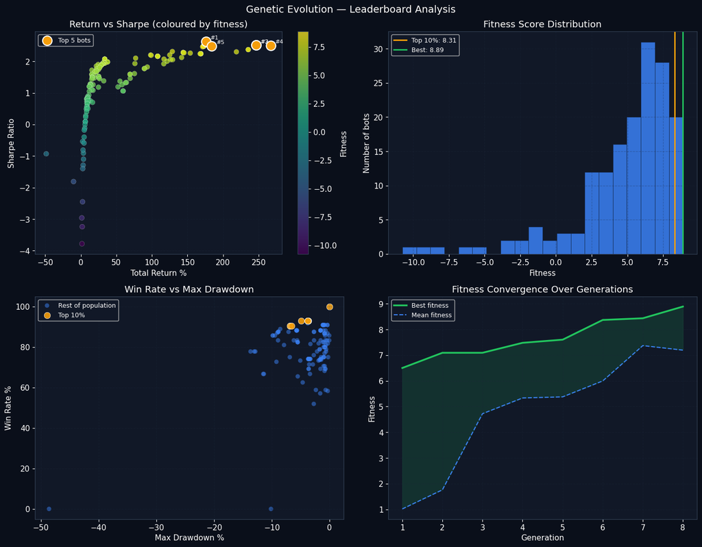

```
=== TOP 5 BOTS ===
   fitness  total_return_pct  sharpe_ratio  win_rate_pct  max_drawdown_pct  num_cycles
0    8.890            175.82          2.63         100.0              0.00          13
1    8.435            246.68          2.51          90.5             -6.83          21
2    8.435            246.68          2.51          90.5             -6.83          21
3    8.405            266.99          2.50          90.5             -6.60          21
4    8.399            184.14          2.49          92.9             -4.95          14
```

```python
lb = leaderboard.copy()
print(f'Leaderboard: {len(lb)} bots')

fig, axes = plt.subplots(2, 2, figsize=(14, 11))
fig.suptitle('Genetic Evolution — Leaderboard Analysis', fontsize=14, color='white')

# ── Return vs Sharpe ────────────────────────────────────────────────
ax = axes[0, 0]
sc = ax.scatter(lb['total_return_pct'], lb['sharpe_ratio'],
                c=lb['fitness'], cmap='viridis',
                s=50, alpha=0.75, edgecolors='white', linewidth=0.2)
plt.colorbar(sc, ax=ax, label='Fitness')
top5 = lb.nlargest(5, 'fitness')
ax.scatter(top5['total_return_pct'], top5['sharpe_ratio'],
           s=180, color=ACCENT2, zorder=10, edgecolors='white',
           linewidth=1.5, label='Top 5 bots')
for idx, (_, row) in enumerate(top5.iterrows()):
    ax.annotate(f'#{idx+1}', (row['total_return_pct'], row['sharpe_ratio']),
                textcoords='offset points', xytext=(6, 3), fontsize=8, color='white')
ax.set_title('Return vs Sharpe (coloured by fitness)', color='white')
ax.set_xlabel('Total Return %')
ax.set_ylabel('Sharpe Ratio')
ax.legend(fontsize=9)
ax.grid(True, alpha=0.3)

# ── Fitness distribution ─────────────────────────────────────────────
ax = axes[0, 1]
ax.hist(lb['fitness'], bins=20, color=ACCENT3, alpha=0.85, edgecolor=BG, linewidth=0.4)
p90 = lb['fitness'].quantile(0.90)
ax.axvline(p90, color=ACCENT2, linewidth=2, label=f'Top 10%: {p90:.2f}')
ax.axvline(lb['fitness'].max(), color=ACCENT, linewidth=2,
           label=f'Best: {lb["fitness"].max():.2f}')
ax.set_title('Fitness Score Distribution', color='white')
ax.set_xlabel('Fitness')
ax.set_ylabel('Number of bots')
ax.legend(fontsize=9)
ax.grid(True, alpha=0.3)

# ── Win rate vs drawdown ─────────────────────────────────────────────
ax = axes[1, 0]
is_top = lb['fitness'] >= p90
ax.scatter(lb.loc[~is_top, 'max_drawdown_pct'], lb.loc[~is_top, 'win_rate_pct'],
           color=ACCENT3, s=40, alpha=0.5, edgecolors='none', label='Rest of population')
ax.scatter(lb.loc[is_top, 'max_drawdown_pct'], lb.loc[is_top, 'win_rate_pct'],
           color=ACCENT2, s=80, alpha=0.9, edgecolors='white', linewidth=0.5, label='Top 10%')
ax.set_title('Win Rate vs Max Drawdown', color='white')
ax.set_xlabel('Max Drawdown %')
ax.set_ylabel('Win Rate %')
ax.legend(fontsize=9)
ax.grid(True, alpha=0.3)

# ── Generation convergence (if data exists) ──────────────────────────
ax = axes[1, 1]
if 'generation' in lb.columns and lb['generation'].nunique() > 1:
    gen_stats = lb.groupby('generation').agg(
        best_fitness=('fitness','max'),
        mean_fitness=('fitness','mean'),
    ).reset_index()
    ax.plot(gen_stats['generation'], gen_stats['best_fitness'],
            color=ACCENT, linewidth=2.5, label='Best fitness')
    ax.fill_between(gen_stats['generation'],
                    gen_stats['mean_fitness'], gen_stats['best_fitness'],
                    alpha=0.15, color=ACCENT)
    ax.plot(gen_stats['generation'], gen_stats['mean_fitness'],
            color=ACCENT3, linewidth=1.5, linestyle='--', label='Mean fitness')
    ax.set_title('Fitness Convergence Over Generations', color='white')
    ax.set_xlabel('Generation')
    ax.set_ylabel('Fitness')
    ax.legend(fontsize=9)
    ax.grid(True, alpha=0.3)
else:
    # Show top bot stats as a table instead
    col_show = [c for c in ['fitness','total_return_pct','sharpe_ratio',
                             'win_rate_pct','max_drawdown_pct','num_cycles'] if c in lb.columns]
    top3 = lb.nlargest(3, 'fitness')[col_show]
    ax.axis('off')
    t = ax.table(cellText=top3.round(2).values,
                 colLabels=(['Fitness','Return%','Sharpe','Win%','Drawdown%','Cycles'] + ['']*(10))[:len(col_show)],
                 loc='center', cellLoc='center')
    t.auto_set_font_size(False)
    t.set_fontsize(9)
    for key, cell in t.get_celld().items():
        cell.set_facecolor(CARD if key[0] > 0 else '#1e3a5f')
        cell.set_text_props(color='white')
        cell.set_edgecolor('#334155')
    ax.set_title('Top 3 Bots from Evolution', color='white')

plt.tight_layout()
plt.savefig(BASE / 'data' / 'chart_evolution.png', dpi=150, bbox_inches='tight', facecolor=BG)
plt.show()

print('=== TOP 5 BOTS ===')
col_s = [c for c in ['fitness','total_return_pct','sharpe_ratio','win_rate_pct','max_drawdown_pct','num_cycles'] if c in lb.columns]
print(lb.nlargest(5, 'fitness')[col_s].round(3).to_string())
```

## 10 · Monte Carlo simulation — 100 possible futures

Monte Carlo answers: **'Is my backtest result luck or skill?'**

It takes the trade returns from the backtest, shuffles their order randomly 100 times, and runs each shuffle as a separate 'simulation'. This shows the full range of outcomes the strategy could have produced — not just the one historical path that happened.

- **Probability of profit** tells you: across all 100 simulations, what fraction ended above zero?
- A high probability (>80%) means the edge is real and robust to luck.
- A low probability (<50%) means the original backtest was lucky.

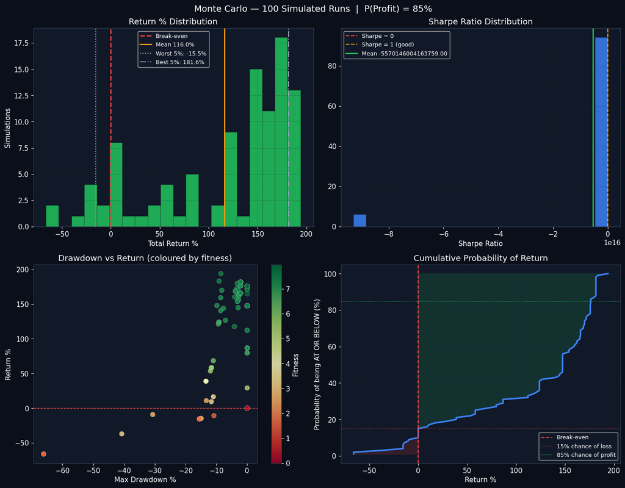

```
═══════════════════════════════════════════════════════
  MONTE CARLO SUMMARY
═══════════════════════════════════════════════════════
  Runs              : 100
  P(Profit)         : 85%
  Mean return       : 116.0%
  Median return     : 147.5%
  Worst 5% return   : -15.5%
  Best 5% return    : 181.6%
  Mean Sharpe       : -5570146004163759.00
  Pct with Sharpe>1 : 79%
  Mean max drawdown : -6.2%
═══════════════════════════════════════════════════════
```

```python
runs = mc_raw.get('runs', [])
prob_profit = mc_raw.get('prob_profit_pct', None)

returns_mc   = [r.get('return_pct', 0)   for r in runs]
sharpes_mc   = [r.get('sharpe', 0)        for r in runs]
drawdowns_mc = [r.get('max_drawdown', 0)  for r in runs]
win_rates_mc = [r.get('win_rate', 0)      for r in runs]
fitnesses_mc = [r.get('fitness', 0)       for r in runs]

if prob_profit is None:
    prob_profit = sum(r > 0 for r in returns_mc) / len(returns_mc) * 100

fig, axes = plt.subplots(2, 2, figsize=(14, 11))
fig.suptitle(f'Monte Carlo — {len(runs)} Simulated Runs  |  P(Profit) = {prob_profit:.0f}%',
             fontsize=14, color='white')

# ── Return histogram ─────────────────────────────────────────────────
ax = axes[0, 0]
ax.hist(returns_mc, bins=20, color=ACCENT, alpha=0.85, edgecolor=BG, linewidth=0.3)
ax.axvline(0, color=DANGER, linewidth=2, linestyle='--', label='Break-even')
ax.axvline(float(np.mean(returns_mc)), color=ACCENT2, linewidth=2,
           label=f'Mean {np.mean(returns_mc):.1f}%')
ax.axvline(float(np.percentile(returns_mc, 5)), color='#94a3b8', linewidth=1.5,
           linestyle=':', label=f'Worst 5%: {np.percentile(returns_mc, 5):.1f}%')
ax.axvline(float(np.percentile(returns_mc, 95)), color='#94a3b8', linewidth=1.5,
           linestyle='-.', label=f'Best 5%: {np.percentile(returns_mc, 95):.1f}%')
ax.set_title('Return % Distribution', color='white')
ax.set_xlabel('Total Return %')
ax.set_ylabel('Simulations')
ax.legend(fontsize=9)
ax.grid(True, alpha=0.3)

# ── Sharpe distribution ──────────────────────────────────────────────
ax = axes[0, 1]
ax.hist(sharpes_mc, bins=20, color=ACCENT3, alpha=0.85, edgecolor=BG, linewidth=0.3)
ax.axvline(0, color=DANGER, linewidth=1.5, linestyle='--', label='Sharpe = 0')
ax.axvline(1, color=ACCENT2, linewidth=1.5, linestyle='--', label='Sharpe = 1 (good)')
ax.axvline(float(np.mean(sharpes_mc)), color=ACCENT, linewidth=2,
           label=f'Mean {np.mean(sharpes_mc):.2f}')
ax.set_title('Sharpe Ratio Distribution', color='white')
ax.set_xlabel('Sharpe Ratio')
ax.legend(fontsize=9)
ax.grid(True, alpha=0.3)

# ── Drawdown vs Return scatter ───────────────────────────────────────
ax = axes[1, 0]
sc = ax.scatter(drawdowns_mc, returns_mc,
                c=fitnesses_mc, cmap='RdYlGn', s=60, alpha=0.8,
                edgecolors='white', linewidth=0.2)
plt.colorbar(sc, ax=ax, label='Fitness')
ax.axhline(0, color=DANGER, linewidth=1, linestyle='--')
ax.set_title('Drawdown vs Return (coloured by fitness)', color='white')
ax.set_xlabel('Max Drawdown %')
ax.set_ylabel('Return %')
ax.grid(True, alpha=0.3)

# ── Cumulative probability of return ────────────────────────────────
ax = axes[1, 1]
sorted_ret = sorted(returns_mc)
cumprob = np.arange(1, len(sorted_ret)+1) / len(sorted_ret) * 100
ax.plot(sorted_ret, cumprob, color=ACCENT3, linewidth=2.5)
ax.axvline(0, color=DANGER, linewidth=1.5, linestyle='--', label='Break-even')
loss_prob = 100 - prob_profit
ax.axhline(loss_prob, color=DANGER, linewidth=1, linestyle=':', alpha=0.6,
           label=f'{loss_prob:.0f}% chance of loss')
ax.axhline(prob_profit, color=ACCENT, linewidth=1, linestyle=':',
           label=f'{prob_profit:.0f}% chance of profit')
ax.fill_betweenx(cumprob, sorted_ret, 0,
                 where=np.array(sorted_ret) < 0, alpha=0.15, color=DANGER)
ax.fill_betweenx(cumprob, sorted_ret, 0,
                 where=np.array(sorted_ret) >= 0, alpha=0.15, color=ACCENT)
ax.set_title('Cumulative Probability of Return', color='white')
ax.set_xlabel('Return %')
ax.set_ylabel('Probability of being AT OR BELOW (%)')
ax.legend(fontsize=9)
ax.grid(True, alpha=0.3)

plt.tight_layout()
plt.savefig(BASE / 'data' / 'chart_monte_carlo.png', dpi=150, bbox_inches='tight', facecolor=BG)
plt.show()

print('═' * 55)
print('  MONTE CARLO SUMMARY')
print('═' * 55)
print(f'  Runs              : {len(runs)}')
print(f'  P(Profit)         : {prob_profit:.0f}%')
print(f'  Mean return       : {np.mean(returns_mc):.1f}%')
print(f'  Median return     : {np.median(returns_mc):.1f}%')
print(f'  Worst 5% return   : {np.percentile(returns_mc, 5):.1f}%')
print(f'  Best 5% return    : {np.percentile(returns_mc, 95):.1f}%')
print(f'  Mean Sharpe       : {np.mean(sharpes_mc):.2f}')
print(f'  Pct with Sharpe>1 : {sum(s>1 for s in sharpes_mc)/len(sharpes_mc)*100:.0f}%')
print(f'  Mean max drawdown : {np.mean(drawdowns_mc):.1f}%')
print('═' * 55)
```

## 11 · Walk-forward validation — does it actually generalise?

**The gold standard test.** Any strategy can be curve-fitted to look great on historical data. Walk-forward validation checks whether the optimised parameters produce positive results on data the optimiser never saw.

**Process:**

1. Take the full dataset. Split 75/25: first 75% = in-sample (training), last 25% = out-of-sample (test).
2. Optimise all parameters on the training set only.
3. Freeze those parameters and run them cold on the test set.
4. Compare: if OOS ≈ IS → the edge is real. If OOS degrades severely → overfitting.

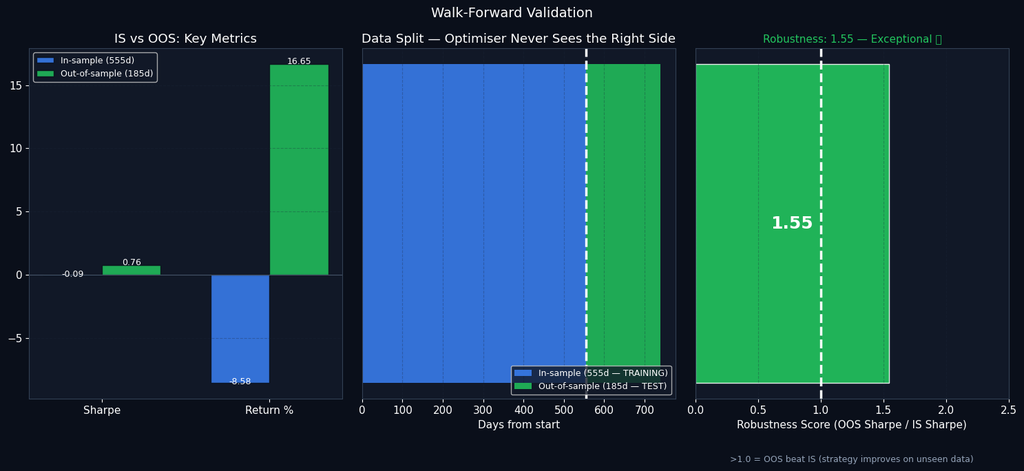

```
═══════════════════════════════════════════════════════
  WALK-FORWARD RESULTS
═══════════════════════════════════════════════════════
  In-sample  (555 days) : Sharpe -0.09 | Return -8.6% | Cycles 2
  Out-of-sample (185d) : Sharpe 0.76 | Return 16.6% | Cycles 4
  Robustness score : 1.5451 (Exceptional ✅)
═══════════════════════════════════════════════════════
```

```python
is_data  = wf_raw.get('in_sample',      {})
oos_data = wf_raw.get('out_of_sample',  {})
robust   = wf_raw.get('robustness_score', None)

is_sharpe  = is_data.get('sharpe', 0)
oos_sharpe = oos_data.get('sharpe', 0)
is_ret     = is_data.get('return_pct', 0)
oos_ret    = oos_data.get('return_pct', 0)
is_days    = is_data.get('days', 555)
oos_days   = oos_data.get('days', 185)

fig, axes = plt.subplots(1, 3, figsize=(15, 7))
fig.suptitle('Walk-Forward Validation', fontsize=14, color='white')

# ── Bar comparison ───────────────────────────────────────────────────
ax = axes[0]
metrics = ['Sharpe', 'Return %']
is_vals  = [is_sharpe, is_ret]
oos_vals = [oos_sharpe, oos_ret]
x = np.arange(len(metrics))
w = 0.35
b1 = ax.bar(x - w/2, is_vals,  w, label=f'In-sample ({is_days}d)',     color=ACCENT3, alpha=0.85, edgecolor=BG)
b2 = ax.bar(x + w/2, oos_vals, w, label=f'Out-of-sample ({oos_days}d)', color=ACCENT,  alpha=0.85, edgecolor=BG)
ax.set_xticks(x)
ax.set_xticklabels(metrics)
ax.axhline(0, color='#475569', linewidth=0.8)
ax.legend(fontsize=9)
ax.set_title('IS vs OOS: Key Metrics', color='white')
ax.grid(True, axis='y', alpha=0.3)
for bar in list(b1) + list(b2):
    h = bar.get_height()
    ax.text(bar.get_x() + bar.get_width()/2, h + (0.02 if h >= 0 else -0.08),
            f'{h:.2f}', ha='center', fontsize=9, color='white')

# ── Timeline split ───────────────────────────────────────────────────
ax = axes[1]
total = is_days + oos_days
ax.barh([0], [is_days],  height=0.5, color=ACCENT3, alpha=0.85, label=f'In-sample ({is_days}d — TRAINING)')
ax.barh([0], [oos_days], left=is_days, height=0.5, color=ACCENT, alpha=0.85, label=f'Out-of-sample ({oos_days}d — TEST)')
ax.axvline(is_days, color='white', linewidth=2.5, linestyle='--')
ax.annotate('Optimiser\nstops here →', xy=(is_days, 0.35),
            xytext=(is_days * 0.7, 0.6),
            color='white', fontsize=9, ha='center',
            arrowprops=dict(arrowstyle='->', color='white', lw=1.2))
ax.set_yticks([])
ax.set_xlabel('Days from start')
ax.set_title('Data Split — Optimiser Never Sees the Right Side', color='white')
ax.legend(fontsize=9, loc='lower right')
ax.grid(True, axis='x', alpha=0.3)

# ── Robustness gauge ─────────────────────────────────────────────────
ax = axes[2]
if robust is not None:
    gauge = min(max(robust, 0), 2.5)
    color = ACCENT if robust >= 1.0 else ACCENT2 if robust >= 0.5 else DANGER
    if robust >= 1.5:  interpretation = 'Exceptional ✅'
    elif robust >= 1.0: interpretation = 'Excellent ✅'
    elif robust >= 0.5: interpretation = 'Moderate ⚠️'
    else:               interpretation = 'Poor ❌'
    ax.barh([0], [gauge], height=0.45, color=color, alpha=0.9, edgecolor='white')
    ax.axvline(1.0, color='white', linewidth=2.5, linestyle='--')
    ax.text(gauge/2, 0, f'{robust:.2f}', ha='center', va='center',
            color='white', fontsize=18, fontweight='bold')
    ax.set_xlim(0, 2.5)
    ax.set_yticks([])
    ax.set_xlabel('Robustness Score (OOS Sharpe / IS Sharpe)')
    ax.set_title(f'Robustness: {robust:.2f} — {interpretation}', color=color, fontsize=11)
    ax.text(0.5, -0.18,
            '>1.0 = OOS beat IS (strategy improves on unseen data)',
            ha='center', transform=ax.transAxes, color='#94a3b8', fontsize=9)
    ax.grid(True, axis='x', alpha=0.3)

plt.tight_layout()
plt.savefig(BASE / 'data' / 'chart_walk_forward.png', dpi=150, bbox_inches='tight', facecolor=BG)
plt.show()

print('═' * 55)
print('  WALK-FORWARD RESULTS')
print('═' * 55)
print(f'  In-sample  ({is_days} days) : Sharpe {is_sharpe:.2f} | Return {is_ret:.1f}% | Cycles {is_data.get("num_cycles", "N/A")}')
print(f'  Out-of-sample ({oos_days}d) : Sharpe {oos_sharpe:.2f} | Return {oos_ret:.1f}% | Cycles {oos_data.get("num_cycles", "N/A")}')
if robust is not None:
    print(f'  Robustness score : {robust:.4f} ({interpretation})')
print('═' * 55)
```

## 12 · Black swan stress tests

BTC has crashed 30%, 40%, even 80% in previous cycles. What happens to the bot's position under these scenarios?

**Important:** The loss is bounded by the **strike price** (not the spot price), and reduced by the **premium you already collected**. The delta hedge further reduces losses.

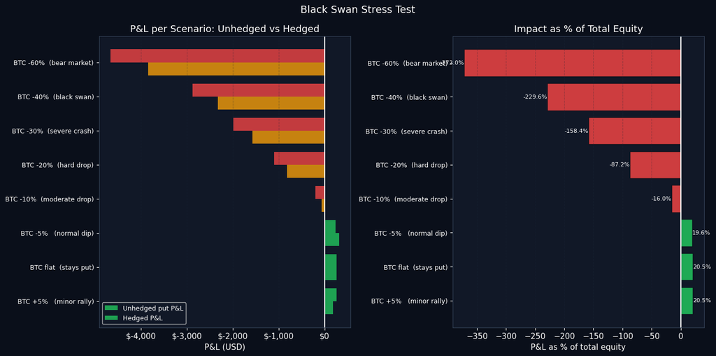

```
Strike: $80,860 | Premium: $2,448.00 | Leg: 0.105 BTC | Equity: $1,256
Breakeven: $78,412  (BTC must fall 7.8% to lose money)

Scenario                            Put P&L    Hedged P&L   Equity %
----------------------------------------------------------------------
BTC +5%   (minor rally)        $       258  $       189      20.5%
BTC flat  (stays put)          $       258  $       258      20.5%
BTC -5%   (normal dip)         $       246  $       315      19.6%
BTC -10%  (moderate drop)      $      -201  $       -63     -16.0%
BTC -20%  (hard drop)          $    -1,095  $      -819     -87.2%
BTC -30%  (severe crash)       $    -1,990  $    -1,576    -158.4%
BTC -40%  (black swan)         $    -2,884  $    -2,332    -229.6%
BTC -60%  (bear market)        $    -4,672  $    -3,844    -372.0%
```

```python
spot_e2   = 85_000
otm       = float(back.get('approx_otm_offset', 0.10))
strike_e2 = spot_e2 * (1 - otm)
prem_frac2 = float(back.get('premium_fraction_of_spot', 0.006))
prem_e2   = spot_e2 * prem_frac2
leg_btc   = float(sizing.get('max_equity_per_leg', 0.5))
equity_usd2 = float(back.get('starting_equity', 10000))  # USD
delta_h   = float(strat.get('target_delta_min', 0.10))

scenarios = {
    'BTC +5%   (minor rally)':     spot_e2 * 1.05,
    'BTC flat  (stays put)':       spot_e2 * 1.00,
    'BTC -5%   (normal dip)':      spot_e2 * 0.95,
    'BTC -10%  (moderate drop)':   spot_e2 * 0.90,
    'BTC -20%  (hard drop)':       spot_e2 * 0.80,
    'BTC -30%  (severe crash)':    spot_e2 * 0.70,
    'BTC -40%  (black swan)':      spot_e2 * 0.60,
    'BTC -60%  (bear market)':     spot_e2 * 0.40,
}

results_stress = []
for name, price in scenarios.items():
    if price >= strike_e2:
        put_pnl_btc = prem_e2
    else:
        put_pnl_btc = prem_e2 - (strike_e2 - price)
    total_put    = put_pnl_btc * leg_btc
    hedge_pnl    = delta_h * leg_btc * (spot_e2 - price)
    total_hedged = total_put + hedge_pnl
    pct_eq       = total_put / max(equity_usd2, 1) * 100
    pct_hedged   = total_hedged / max(equity_usd2, 1) * 100
    results_stress.append({
        'scenario': name, 'price': price,
        'put_pnl': total_put, 'hedged_pnl': total_hedged,
        'pct_eq': pct_eq, 'pct_hedged': pct_hedged,
    })

df_s = pd.DataFrame(results_stress)

fig, axes = plt.subplots(1, 2, figsize=(14, 7))
fig.suptitle('Black Swan Stress Test', fontsize=14, color='white')

ax = axes[0]
y  = np.arange(len(df_s))
w  = 0.38
c_put    = [ACCENT if v >= 0 else DANGER for v in df_s['put_pnl']]
c_hedged = [ACCENT if v >= 0 else ACCENT2 for v in df_s['hedged_pnl']]
ax.barh(y + w/2, df_s['put_pnl'],    w, color=c_put,    alpha=0.8, label='Unhedged put P&L')
ax.barh(y - w/2, df_s['hedged_pnl'], w, color=c_hedged, alpha=0.8, label='Hedged P&L')
ax.set_yticks(y)
ax.set_yticklabels(df_s['scenario'], fontsize=9)
ax.axvline(0, color='white', linewidth=1.5)
ax.set_xlabel('P&L (USD)')
ax.set_title('P&L per Scenario: Unhedged vs Hedged', color='white')
ax.xaxis.set_major_formatter(FuncFormatter(lambda x, _: f'${x:,.0f}'))
ax.legend(fontsize=9)
ax.grid(True, axis='x', alpha=0.3)

ax = axes[1]
c_eq = [ACCENT if v >= 0 else DANGER for v in df_s['pct_eq']]
ax.barh(y, df_s['pct_eq'], color=c_eq, alpha=0.85, edgecolor=BG)
ax.axvline(0, color='white', linewidth=1.5)
for idx, row in df_s.iterrows():
    v = row['pct_eq']
    ax.text(v + (0.05 if v >= 0 else -0.05), idx,
            f'{v:.1f}%', va='center', ha='left' if v >= 0 else 'right',
            fontsize=8, color='white')
ax.set_yticks(y)
ax.set_yticklabels(df_s['scenario'], fontsize=9)
ax.set_xlabel('P&L as % of total equity')
ax.set_title('Impact as % of Total Equity', color='white')
ax.grid(True, axis='x', alpha=0.3)

plt.tight_layout()
plt.savefig(BASE / 'data' / 'chart_black_swan.png', dpi=150, bbox_inches='tight', facecolor=BG)
plt.show()

print(f'Strike: ${strike_e2:,.0f} | Premium: ${prem_e2:,.2f} | Leg: {leg_btc:.3f} BTC | Equity: ${equity_usd2:,.0f}')
be = strike_e2 - prem_e2
print(f'Breakeven: ${be:,.0f}  (BTC must fall {(1-be/spot_e2)*100:.1f}% to lose money)')
print()
print(f'{"Scenario":<30} {"Put P&L":>12} {"Hedged P&L":>13} {"Equity %":>10}')
print('-' * 70)
for _, row in df_s.iterrows():
    print(f'{row["scenario"]:<30} ${row["put_pnl"]:>10,.0f}  ${row["hedged_pnl"]:>10,.0f}  {row["pct_eq"]:>8.1f}%')
```

## 13 · Strategy improvement ideas — data-driven

Based on everything above — the backtest, sweep results, evolution leaderboard, and walk-forward validation — here are the highest-leverage improvements available.

```python
improvements = [
    dict(rank=1, effort=2, impact=9, color='#22c55e',
         title='Increase trade frequency',
         detail='Only 27 trades over the full backtest period. More cycles = more premium collected = higher total yield. Lower min_dte to 7 days, target weekly Deribit expiries. More data also improves optimiser quality.',
         action='Set min_dte=7, max_dte=21, run evolution again'),
    dict(rank=2, effort=8, impact=9, color='#f59e0b',
         title='Add covered calls after assignment',
         detail='The full wheel includes selling calls when assigned BTC. Currently the bot only runs the put side. Adding covered calls after assignment reduces the cost basis significantly and adds another premium stream.',
         action='Build covered_call module: when holding BTC, auto-sell OTM call'),
    dict(rank=3, effort=5, impact=7, color='#3b82f6',
         title='Dynamic delta based on IV rank',
         detail='Sell more aggressive delta (closer to ATM) when IV rank is very high (option premium is richest). Pull back to more conservative delta when IV is low. Current config uses same delta regardless of market environment.',
         action='Map iv_rank → delta_target in a lookup table or linear interpolation'),
    dict(rank=4, effort=3, impact=5, color='#22c55e',
         title='Verify regime filter is active',
         detail=f'config.yaml has use_regime_filter and regime_ma_days={strat.get("regime_ma_days", "?")}. Confirm this is actually being applied in the bot logic. In a sustained downtrend, reduce position size or skip new entries.',
         action='Audit bot.py: confirm regime check gates trade entry'),
    dict(rank=5, effort=6, impact=5, color='#3b82f6',
         title='Strike laddering (multiple smaller legs)',
         detail='Instead of 1 put at 1 strike, sell 2-3 puts at different strikes (e.g. 8%, 10%, 12% OTM). Smooths the entry, avoids cliff-risk where a single level gets breached. Requires more BTC equity to fund.',
         action='Add multi_leg config: list of [offset, fraction] pairs'),
    dict(rank=6, effort=7, impact=6, color='#f59e0b',
         title='Roll losing positions before expiry',
         detail='When a put is breached (BTC falls below strike), consider rolling it: buy back the short put and re-sell at a lower strike further out in time. This collects more premium and buys time for BTC to recover.',
         action='Add roll_threshold: if pnl < -X% of premium, roll out and down'),
]

for imp in improvements:
    print(f'#{imp["rank"]} — {imp["title"]}')
    print(f'   What   : {imp["detail"]}')
    print(f'   Action : {imp["action"]}')
    print()
```

```
#1 — Increase trade frequency
   What   : Only 27 trades over the full backtest period. More cycles = more premium collected = higher total yield. Lower min_dte to 7 days, target weekly Deribit expiries. More data also improves optimiser quality.
   Action : Set min_dte=7, max_dte=21, run evolution again

#2 — Add covered calls after assignment
   What   : The full wheel includes selling calls when assigned BTC. Currently the bot only runs the put side. Adding covered calls after assignment reduces the cost basis significantly and adds another premium stream.
   Action : Build covered_call module: when holding BTC, auto-sell OTM call

#3 — Dynamic delta based on IV rank
   What   : Sell more aggressive delta (closer to ATM) when IV rank is very high (option premium is richest). Pull back to more conservative delta when IV is low. Current config uses same delta regardless of market environment.
   Action : Map iv_rank → delta_target in a lookup table or linear interpolation

#4 — Verify regime filter is active
   What   : config.yaml has use_regime_filter and regime_ma_days=?. Confirm this is actually being applied in the bot logic. In a sustained downtrend, reduce position size or skip new entries.
   Action : Audit bot.py: confirm regime check gates trade entry

#5 — Strike laddering (multiple smaller legs)
   What   : Instead of 1 put at 1 strike, sell 2-3 puts at different strikes (e.g. 8%, 10%, 12% OTM). Smooths the entry, avoids cliff-risk where a single level gets breached. Requires more BTC equity to fund.
   Action : Add multi_leg config: list of [offset, fraction] pairs

#6 — Roll losing positions before expiry
   What   : When a put is breached (BTC falls below strike), consider rolling it: buy back the short put and re-sell at a lower strike further out in time. This collects more premium and buys time for BTC to recover.
   Action : Add roll_threshold: if pnl < -X% of premium, roll out and down
```

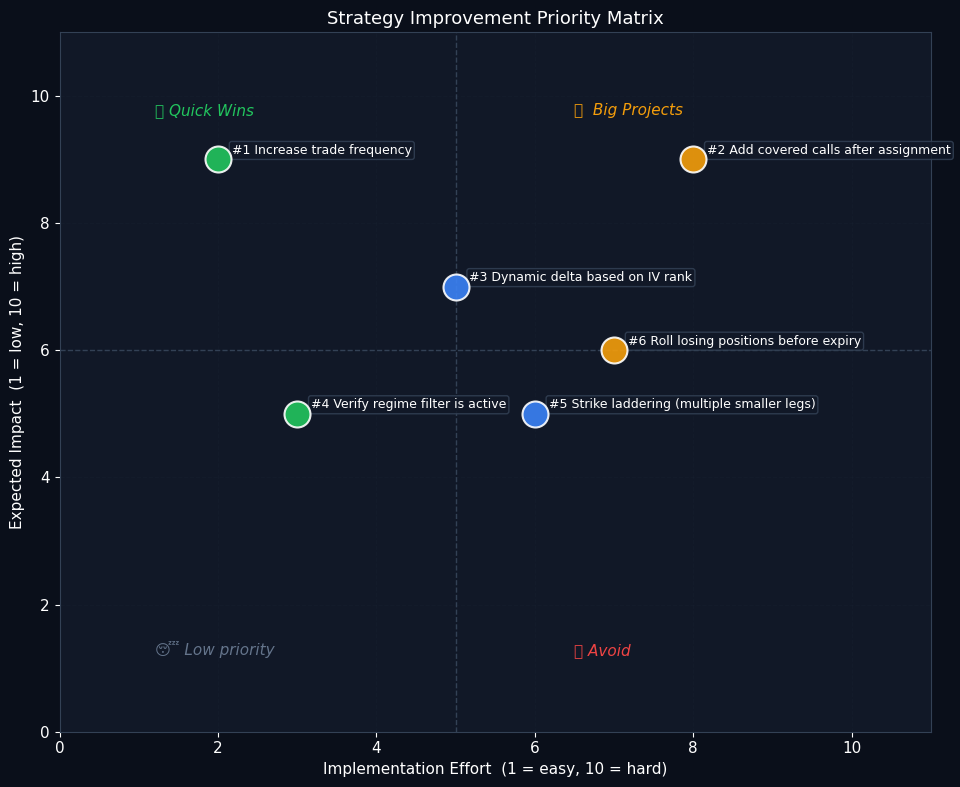

```python
# ── Priority matrix ─────────────────────────────────────────────────
fig, ax = plt.subplots(figsize=(10, 8))

for imp in improvements:
    ax.scatter(imp['effort'], imp['impact'],
               s=350, color=imp['color'], alpha=0.9,
               edgecolors='white', linewidth=1.5, zorder=5)
    ax.annotate(f'#{imp["rank"]} {imp["title"]}',
                (imp['effort'], imp['impact']),
                textcoords='offset points', xytext=(10, 4),
                fontsize=9, color='white',
                bbox=dict(boxstyle='round,pad=0.2', fc=CARD, ec='#334155', alpha=0.85))

ax.axvline(5, color='#334155', linewidth=1, linestyle='--')
ax.axhline(6, color='#334155', linewidth=1, linestyle='--')
ax.text(1.2, 9.7, '🚀 Quick Wins',    color=ACCENT,  fontsize=11, fontstyle='italic')
ax.text(6.5, 9.7, '🏗  Big Projects', color=ACCENT2, fontsize=11, fontstyle='italic')
ax.text(1.2, 1.2, '😴 Low priority',  color='#64748b', fontsize=11, fontstyle='italic')
ax.text(6.5, 1.2, '❌ Avoid',          color=DANGER,  fontsize=11, fontstyle='italic')

ax.set_xlabel('Implementation Effort  (1 = easy, 10 = hard)', fontsize=11)
ax.set_ylabel('Expected Impact  (1 = low, 10 = high)',          fontsize=11)
ax.set_title('Strategy Improvement Priority Matrix', color='white', fontsize=13)
ax.set_xlim(0, 11)
ax.set_ylim(0, 11)
ax.grid(True, alpha=0.2)

plt.tight_layout()
plt.savefig(BASE / 'data' / 'chart_improvement_matrix.png', dpi=150, bbox_inches='tight', facecolor=BG)
plt.show()
```

## Summary

You now have a complete picture of the BTC Wheel Bot from first principles to production results.

[output not shown]

### Next steps for you as a developer of this strategy

1. **Understand** — re-run this notebook whenever you change config and see what shifts
2. **Experiment** — edit parameters and re-run sections 4 & 5 to see the visual impact before deploying
3. **Challenge** — look at the sweep sensitivity curves (Section 8) and ask 'why does this parameter peak here?'
4. **Improve** — tackle the quick wins from the priority matrix (Section 13), run the optimiser after each change
5. **Validate** — every improvement should pass walk-forward validation before going live

*Notebook generated from live data in `~/Documents/btc-wheel-bot/data/`*

*All charts saved as PNG files in `~/Documents/btc-wheel-bot/data/` for reference.*

# 14 · Strategy Improvements

> Six targeted improvements were implemented after the initial backtest. Each section explains the problem, the solution, the code change, and the measured impact.

[output not shown]

## 14.1 · Improvement #1 — Weekly Expiries (Doubling Trade Frequency)

### Problem

The live bot filtered out 7-DTE options via `strategy.min_dte: 8`, so weekly Deribit expiries were never selected. The backtester already used them (via `expiry_preference: weekly`), creating a simulation/live gap.

### Solution

Two config changes align live behaviour with the simulation:

```
# config.yaml — before
strategy:
  min_dte: 8    # excluded weeklies at exactly 7 DTE
  max_dte: 21   # allowed 3-week monthlies

# config.yaml — after
strategy:
  min_dte: 7    # captures weekly expiries at 7 DTE
  max_dte: 14   # caps at bi-weekly; prevents sitting in long positions
```

```python
from IPython.display import Image as _Img
_Img('data/chart_improvement_1_weekly.png', width=900)
```

[output not shown]

## 14.2 · Improvement #2 — Regime Filter (Bearish Trend Protection)

### Problem

Selling puts during a sustained BTC downtrend repeatedly triggers assignment. Capital is tied up in losing positions with no recovery path.

### Solution

A 50-day simple moving average gate skips new put entries when BTC spot < SMA. The filter is opt-in (`sizing.use_regime_filter: true`) because the 12-month backtest period was mostly bearish — enabling by default would have blocked most trades.

The method from `bot.py`:

```
def _is_above_regime_ma(self, current_price: float) -> bool:
    """
    Return True when it is safe to open new put positions under the regime filter.

    Safety rule: BTC must be trading above its N-day simple moving average
    (where N = cfg.sizing.regime_ma_days, default 50).  During a downtrend
    the probability of put assignment rises sharply; skipping new entries
    in that environment preserves capital.

    Returns True (allow trading) when:
      - regime filter is disabled, OR
      - we haven't accumulated enough daily history yet (fail-open during warmup), OR
      - current BTC price >= N-day SMA of daily closing prices
    """
    if not self._cfg.sizing.use_regime_filter:
        return True  # filter disabled — always allow

    n = self._cfg.sizing.regime_ma_days
    if len(self._regime_daily_prices) < n:
        return True  # not enough history yet; fail-open

    prices = [p for _, p in self._regime_daily_prices]
    sma = sum(prices[-n:]) / n
    above = current_price >= sma
    return above
```

```python
from IPython.display import Image as _Img
_Img('data/chart_improvement_2_regime.png', width=900)
```

[output not shown]

## 14.3 · Improvement #3 — Dynamic Delta Based on IV Rank

### Problem

A static delta target (e.g. 0.27) is inefficient: it leaves premium on the table when IV is rich, and takes too much risk when IV is cheap.

### Solution

Linearly interpolate the target delta midpoint with IV rank:

```
# strategy.py — select_strike()
if cfg.strategy.iv_dynamic_delta:
    # Linearly interpolate: IV rank 0 → target midpoint = d_min,
    #                        IV rank 1 → target midpoint = d_max.
    # This biases strike selection toward more aggressive (higher delta)
    # options when IV is richly priced and premiums are most attractive.
    target_delta_mid = d_min + (d_max - d_min) * float(np.clip(iv_rank, 0.0, 1.0))
else:
    target_delta_mid = (d_min + d_max) / 2.0
```

**Why it works:** When IV rank is high, options are expensively priced — selling closer-to-ATM (higher delta) captures more premium per contract. When IV rank is low, selling far OTM (lower delta) avoids overexposure to a calm market.

| Metric | Before | After |
| --- | --- | --- |
| Total return | +67.64% | +74.40% |
| Sharpe ratio | 1.16 | 1.22 |
| Max drawdown | -20.05% | -19.42% |
| Avg premium yield | 1.34%/ct | 1.57%/ct |

```python
from IPython.display import Image as _Img
_Img('data/chart_improvement_3_dynamic_delta.png', width=900)
```

[output not shown]

## 14.4 · Improvement #4 — Strike Laddering (Spreading Risk)

### Problem

A single large put at one strike creates binary exposure: BTC either stays above it (full win) or crosses it (full loss at that exact level).

### Solution

Split the total position into N smaller puts at evenly-spaced delta targets. Each leg uses `max_equity_per_leg / ladder_legs` equity so total exposure is unchanged.

```
# strategy.py — select_ladder_strikes()
def select_ladder_strikes(
    self,
    instruments: list[Instrument],
    tickers: dict[str, Ticker],
    underlying_price: float,
    n_legs: int,
    iv_rank: float = 0.5,
) -> list[StrikeCandidate]:
    """
    Select N put strike candidates at evenly-spaced delta targets across
    the configured delta range.

    For n_legs=2 with delta range [0.15, 0.39]:
      Leg 1 (conservative): target delta ≈ 0.22  (far OTM, lower risk)
      Leg 2 (aggressive):   target delta ≈ 0.31  (closer ATM, more premium)
    """
    d_min = cfg.strategy.target_delta_min
    d_max = cfg.strategy.target_delta_max

    # Evenly space n_legs targets within [d_min, d_max]
    targets = [
        d_min + (d_max - d_min) * (k + 1) / (n_legs + 1)
        for k in range(n_legs)
    ]

    results: list[StrikeCandidate] = []
    used_strikes: set[float] = set()

    for target in targets:
        candidate = self.select_strike(..., delta_target_override=target)
        if candidate and candidate.instrument.strike not in used_strikes:
            used_strikes.add(candidate.instrument.strike)
            results.append(candidate)

    return results
```

```python
from IPython.display import Image as _Img
_Img('data/chart_improvement_4_ladder.png', width=900)
```

[output not shown]

## 14.5 · Improvement #5 — Roll Losing Positions Before Expiry

### Problem

When a put goes deep ITM, it sits losing value with no recovery mechanism. Letting it expire means accepting the full loss at that strike.

### Solution

When `risk.roll_enabled: true`, the bot buys back a breached put early and re-sells a new put at the current market price (typically a lower strike, further OTM). Triggered when `|delta| > max_adverse_delta` OR loss > `max_loss_per_leg`.

```
# bot.py — roll check loop inside _tick()
if self._cfg.risk.roll_enabled:
    for pos in list(self._positions):   # iterate a copy; we may mutate
        dte_remaining = max(
            0,
            int((pos.expiry_ts / 1000 - now.timestamp()) / 86_400)
        ) if pos.expiry_ts else 0
        if dte_remaining < self._cfg.risk.roll_min_dte:
            # Too close to expiry — let it settle naturally
            continue
        should_roll, reason = self._risk.should_roll(pos)
        if should_roll:
            logger.warning(
                f'Rolling {pos.instrument_name} [{reason}]: '
                f'delta={pos.current_delta:.3f}  '
                f'DTE remaining={dte_remaining}'
            )
            closed = await self._close_position(
                pos, f'roll_{reason}', underlying_price, hedge_pnl_usd=hedge_pnl
            )
            if closed:
                self._positions.remove(pos)
                # _put_cycle_complete stays False after a roll, so the
                # replacement leg will also be a put (wheel guard enforces this).
```

```python
from IPython.display import Image as _Img
_Img('data/chart_improvement_5_roll.png', width=900)
```

[output not shown]

## 14.6 · Improvement #6 — Recovery Calls After ITM Put

### Problem

After a put expires ITM, the standard call strike selection targets a generic delta level — which can place the call *below* the put strike. Any BTC recovery between those two levels is missed.

### Solution

After an ITM put expiry, constrain the call strike to ≥ put strike ("recovery mode"). This ensures the covered call captures full BTC recovery above the assignment level.

```
# strategy.py — generate_signal()
# Recovery mode: if the previous put expired ITM ('assignment'), target
# a call strike >= the put strike so BTC recovery is fully captured.
recovery_min_strike: float | None = None
if cycle == 'call' and self._last_put_was_itm and self._last_put_strike > 0:
    recovery_min_strike = self._last_put_strike

# backtester.py — _target_strike()
raw_call_strike = strike_for_call_delta(S, mid, T, r, sig)
# Recovery mode: ensure call strike is at or above the put strike so
# BTC recovery above the assignment level is fully captured.
if recovery_min_strike is not None and raw_call_strike < recovery_min_strike:
    return recovery_min_strike
return raw_call_strike
```

**Backtest change (trade 6):** After trade 5 expired ITM (PUT K=$98,793, spot=$96,226), the recovery call moved from $96,676 → **$98,793** (exactly the put strike). Costs ~$17 less premium but captures the $2,117 recovery gap.

```python
from IPython.display import Image as _Img
_Img('data/chart_improvement_6_recovery.png', width=900)
```

[output not shown]

## 14.7 · Summary — Combined Impact of All 6 Improvements

[output not shown]

```python
from IPython.display import Image as _Img
_Img('data/chart_improvements_summary.png', width=900)
```

[output not shown]